# Simulating a Turing Machine with Python and executing programs on it

In this article, we shall implement a basic version of a Turing Machine in python and write a few simple programs to execute them on the Turing machine. This article is inspired by the edX / MITx course Paradox and Infinity and few of the programs to be executed on the (simulated) Turing machine are taken from the course. Also, some programs are from this Cambridge tutorial.

## A few Definitions

Let’s start by defining a Turing machine (originally invented by Alan Turing) formally, as is shown in the following figure:

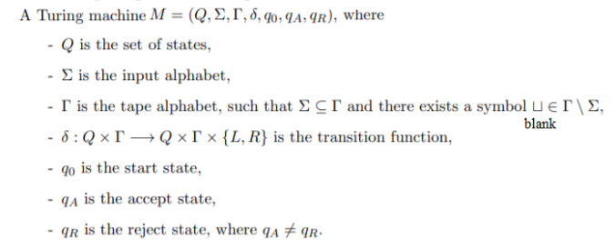

In this article, we shall assume that the tape alphabet can contain only the symbols {0,1,⊔}, the head on the Turing machine moves in left (L) / right (R) direction (D) or doesn’t move (*), upon reading a symbol on the tape (i.,e., D can be one of {L,R,*}). Also, given a program along with a valid input, the Turing machine just halts (goes to the state halt) after writing the desired output on its tape.

## The python implementation for simulating a Turing Machine

The following python code shows a very simple implementation of a Turing machine. It accepts a program as a string, with each transition function defined on a new line. The state halt is denoted by H.

```python
N = 1000 # tape length, initialize to a large value

class TuringMachine:

   '''
   initialize the Turing Machine, read the program and input
   '''
   def __init__(self, program, input, state=0):
     self.trf = {}
     self.state = str(state)
     self.tape = ''.join(['_']*N)
     self.head = N // 2   # head is positioned in the middle
     self.tape = self.tape[:self.head] + input + self.tape[self.head:]
     for line in program.splitlines():
       s, a, r, d, s1 = line.split(' ')
       self.trf[s,a] = (r, d, s1)

   '''
   step through a program
   '''
   def step(self):
     if self.state != 'H':
        # assert self.head >= 0 and self.head < len(self.tape) here
        a = self.tape[self.head]
        action = self.trf.get((self.state, a))
        if action:
           r, d, s1 = action
           self.tape = self.tape[:self.head] + r + self.tape[self.head+1:]
           if d != '*':
              self.head = self.head + (1 if d == 'r' else -1)
           self.state = s1
           print(self.tape.replace('_', ''), self.state)

   '''
   run a program
   '''
   def run(self, max_iter=9999):
      iter = 0
      while self.state != 'H' and iter < max_iter: # prevent infinite loop
          self.step()
          iter += 1
      print(self.tape.replace('_', ''), self.state)
```

In the next section we shall show how a program on this Turing Machine will look like and how to run such a program, by instantiating the above class. We shall demonstrate with a few programs.

## 1. Binary Addition with Turing Machine

The following figure shows how to perform binary addition with a Turing machine, where the binary numbers to be added are input to the Turing machine and are separated by a single blank. The TM header is assumed to be positioned at the leftmost position of the first number, in the very beginning.

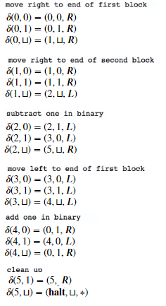

Given the two binary numbers, the Turing Machine

- uses the second number as a counter
- decrements the second number by one
- increments the first number by one
- till the second number becomes 0.

The following code shows how the above program can be run to add two input binary numbers 1101 (decimal 13) and 101 (decimal 5) to output the binary number 10010 (decimal 18). The final state of the machine is H (halt), as expected.

```python
input = '1101_101'
program = open('program.txt').read()
tm = TuringMachine(program, input)
tm.run()
# 10010 H
```

```
1101101 0
1101101 0
1101101 0
1101101 0
1101101 1
1101101 1
1101101 1
1101101 1
1101101 2
1101100 3
1101100 3
1101100 3
1101100 4
1100100 4
1110100 0
```

[output cut: 65 more lines]

The following animation shows how the binary numbers are added using the TM simulator.

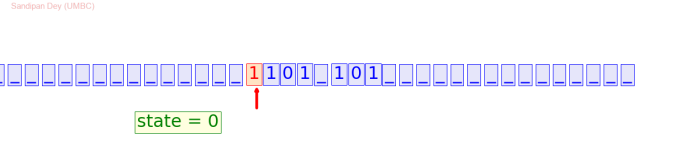